# Statistische Inferenz und Regressionsanalyse

Statistik Masterkurs

2025-04-04

# Übersicht

- **Einführung**: Datensatz und Überblick
- **t-Test**: Vergleich von Torhütern und Feldspielern (Marktwert)
- **ANOVA**: Vergleich aller Positionsgruppen (Marktwert)
- **Einfache lineare Regression**: Einfluss des Alters auf den Marktwert
- **Multiple Regression**: Kombination von Alter und Position
- **OLS-Regressionsdiagnostik**: BLUE-Eigenschaften und Annahmen

# Datensatzüberblick

```r
glimpse(tbl_buli)
```

```
## Rows: 645
## Columns: 8
## $ name               <chr> "Manuel Neuer", "Yann Sommer", "Sven Ulreich", "Joh…
## $ age                <dbl> 36, 34, 34, 19, 23, 24, 26, 26, 20, 18, 19, 19, 22,…
## $ mv                 <dbl> 7000000, 5000000, 700000, 300000, 75000000, 6000000…
## $ pos_player         <fct> Goalkeeper, Goalkeeper, Goalkeeper, Goalkeeper, Cen…
## $ pos_bin            <fct> Goalkeeper, Goalkeeper, Goalkeeper, Goalkeeper, Fie…
## $ pos_cat            <fct> Goalkeeper, Goalkeeper, Goalkeeper, Goalkeeper, Def…
## $ player_height_mtrs <chr> "1.93", "1.83", "1.92", "1.91", "1.89", "1.86", "1.…
## $ player_foot        <chr> "right", "right", "right", " ", "right", "right", "…
```

```r
tbl_buli %>%
  summarise(
    n = n(),
    mean_age = mean(age, na.rm = TRUE),
    mean_mv = mean(mv, na.rm = TRUE) / 1000000,
    sd_mv = sd(mv, na.rm = TRUE) / 1000000
  ) %>%
  gt() %>%
  fmt_number(columns = c("mean_age", "mean_mv", "sd_mv"), decimals = 2) %>%
  cols_label(
    n = "Spieleranzahl",
    mean_age = "Durchschnittsalter",
    mean_mv = "Durchschnittlicher Marktwert (Mio. €)",
    sd_mv = "Standardabweichung Marktwert (Mio. €)"
  )
```

| Spieleranzahl | Durchschnittsalter | Durchschnittlicher Marktwert (Mio. €) | Standardabweichung Marktwert (Mio. €) |
| --- | --- | --- | --- |
| 645 | 24.71 | 7.35 | 13.46 |

# t-Test: Visualisierung der Daten

Vergleich des Marktwerts zwischen Torhütern und Feldspielern

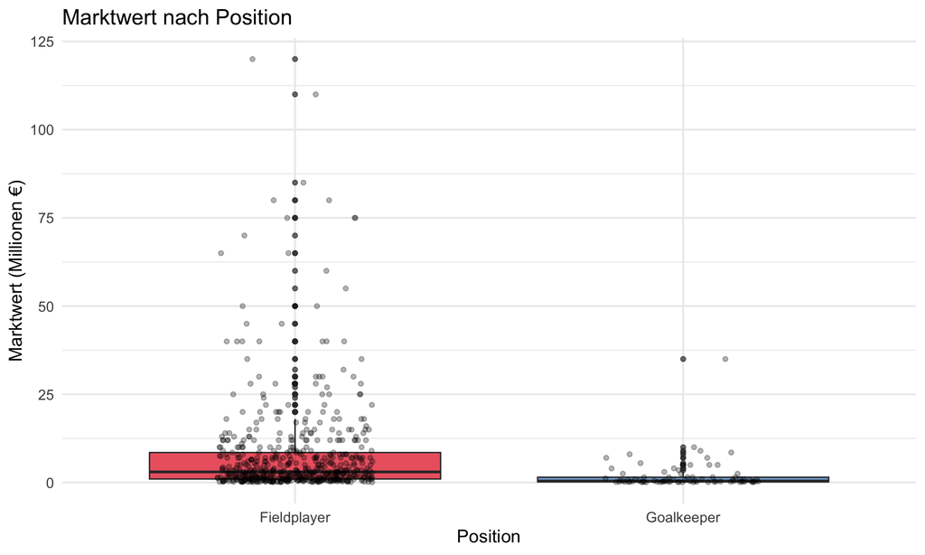

```r
# Visualisierung des Marktwerts nach Position (binär)
tbl_buli %>%
  mutate(mv_mio = mv / 1000000) %>%
  ggplot(aes(x = pos_bin, y = mv_mio, fill = pos_bin)) +
  geom_boxplot(alpha = 0.7) +
  geom_jitter(width = 0.2, alpha = 0.3) +
  scale_fill_brewer(palette = "Set1") +
  labs(
    title = "Marktwert nach Position",
    x = "Position",
    y = "Marktwert (Millionen €)",
    fill = "Position"
  ) +
  theme_minimal(base_size = 14) +
  theme(legend.position = "none")
```

# t-Test mit infer: Resampling-Methode

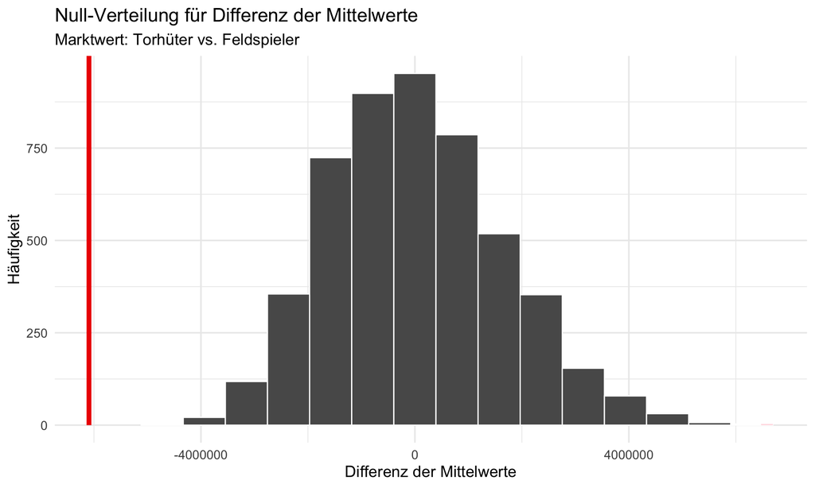

```r
# Resampling mit infer
set.seed(123)
null_dist <- tbl_buli %>%
  drop_na(mv, pos_bin) %>%
  specify(mv ~ pos_bin) %>%
  hypothesize(null = "independence") %>%
  generate(reps = 5000, type = "permute") %>%
  calculate(stat = "diff in means", order = c("Goalkeeper", "Fieldplayer"))

# Beobachtete Differenz berechnen
obs_diff <- tbl_buli %>%
  drop_na(mv, pos_bin) %>%
  specify(mv ~ pos_bin) %>%
  calculate(stat = "diff in means", order = c("Goalkeeper", "Fieldplayer"))

# Visualisierung
null_dist %>%
  visualize() +
  shade_p_value(obs_stat = obs_diff, direction = "two-sided") +
  labs(
    title = "Null-Verteilung für Differenz der Mittelwerte",
    subtitle = "Marktwert: Torhüter vs. Feldspieler",
    x = "Differenz der Mittelwerte",
    y = "Häufigkeit"
  ) +
  theme_minimal(base_size = 14)
```

# p-Wert Berechnung mit infer

```r
# p-Wert berechnen
p_value <- null_dist %>%
  get_p_value(obs_stat = obs_diff, direction = "two-sided")

# Ergebnisse anzeigen
p_value %>%
  gt() %>%
  fmt_number(columns = "p_value", decimals = 4) %>%
  cols_label(p_value = "p-Wert (zweiseitig)")
```

| p-Wert (zweiseitig) |
| --- |
| 0.0000 |

# t-Test: Traditionelle Methode mit infer

```r
# Using infer's t_test function (preferred over stats::t.test here)
t_test_result_traditional <- tbl_buli %>%
  t_test(
    formula = mv ~ pos_bin,
    order = c("Fieldplayer", "Goalkeeper"),
    alternative = "two-sided"
  )

# Extract group means for display
group_means <- tbl_buli %>%
  group_by(pos_bin) %>%
  summarize(mean_value = mean(mv))

# Display t-test results with properly formatted columns
t_test_result_traditional %>%
  gt() %>%
  fmt_number(
    columns = c("statistic", "estimate"),
    decimals = 2
  ) %>%
  fmt_number(
    columns = c("p_value"),
    decimals = 4
  ) %>%
  cols_label(
    statistic = "t-statistic",
    p_value = "p-value",
    estimate = "Mean Difference (€)"
  )
```

| t-statistic | t_df | p-value | alternative | Mean Difference (€) | lower_ci | upper_ci |
| --- | --- | --- | --- | --- | --- | --- |
| 7.83 | 370.0705 | 0.0000 | two.sided | 6,093,242.33 | 4563916 | 7622569 |

```r
# Display group means separately
group_means %>%
  gt() %>%
  fmt_number(
    columns = "mean_value",
    decimals = 2
  ) %>%
  cols_label(
    pos_bin = "Position",
    mean_value = "Mean Market Value (€)"
  )
```

| Position | Mean Market Value (€) |
| --- | --- |
| Fieldplayer | NA |
| Goalkeeper | NA |

# t-Test vs. lineare Regression: Äquivalenz

```r
# t-Test als Regression
lm_ttest <- lm(mv ~ pos_bin, data = tbl_buli)
tidy_lm <- tidy(lm_ttest)

# Ergebnisse anzeigen
tidy_lm %>%
  gt() %>%
  fmt_number(columns = c("estimate", "std.error", "statistic"), decimals = 2) %>%
  fmt_number(columns = c("p.value"), decimals = 4) %>%
  cols_label(
    term = "Term",
    estimate = "Schätzwert",
    std.error = "Standardfehler",
    statistic = "t-Wert",
    p.value = "p-Wert"
  )
```

| Term | Schätzwert | Standardfehler | t-Wert | p-Wert |
| --- | --- | --- | --- | --- |
| (Intercept) | 8,115,117.33 | 565,902.67 | 14.34 | 0.0000 |
| pos_binGoalkeeper | −6,093,242.33 | 1,593,093.92 | −3.82 | 0.0001 |

# Abhängige vs. unabhängige Stichproben

## Unabhängige Stichproben (wie in unserem Fall)

- Messungen stammen von verschiedenen Gruppen/Individuen
- Jede Beobachtung ist unabhängig von anderen Beobachtungen
- Beispiel: Vergleich von Torhütern vs. Feldspielern

## Abhängige Stichproben (repeated measures)

- Messungen stammen von denselben Individuen zu verschiedenen Zeitpunkten
- Beobachtungen sind korreliert
- Beispiel: Marktwertentwicklung derselben Spieler vor und nach der Saison
- Benötigt andere Testverfahren (paired t-test, repeated measures ANOVA, etc.)

# ANOVA: Visualisierung der Daten

Vergleich des Marktwerts zwischen verschiedenen Positionsgruppen

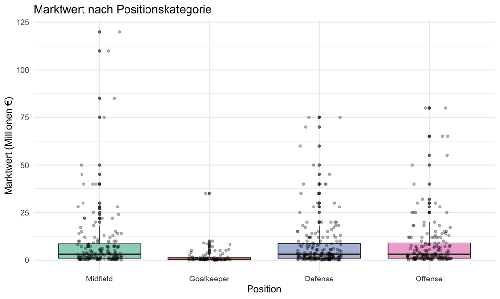

```r
# Visualisierung des Marktwerts nach Positionskategorie
tbl_buli %>%
  drop_na(pos_cat) %>%
  mutate(
    mv_mio = mv / 1000000,
    pos_cat = fct_relevel(pos_cat, "Midfield", "Goalkeeper", "Defense", "Offense")
  ) %>%
  ggplot(aes(x = pos_cat, y = mv_mio, fill = pos_cat)) +
  geom_boxplot(alpha = 0.7) +
  geom_jitter(width = 0.2, alpha = 0.3) +
  scale_fill_brewer(palette = "Set2") +
  labs(
    title = "Marktwert nach Positionskategorie",
    x = "Position",
    y = "Marktwert (Millionen €)",
    fill = "Position"
  ) +
  theme_minimal(base_size = 14) +
  theme(legend.position = "none")
```

# ANOVA mit infer: Resampling-Methode

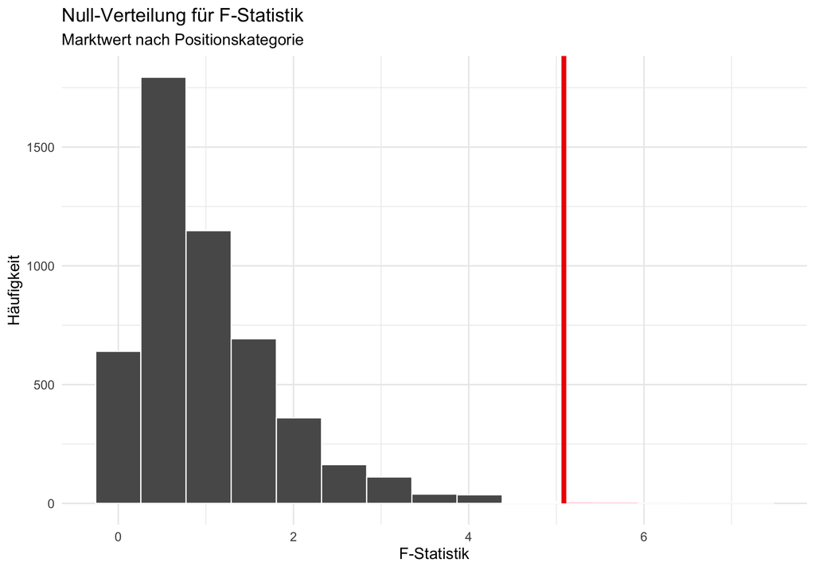

```r
# Resampling mit infer für ANOVA
set.seed(456)

# Referenzlevel setzen
tbl_buli_midfield <- tbl_buli %>%
  drop_na(pos_cat) %>%
  mutate(pos_cat = fct_relevel(pos_cat, "Midfield"))

# Beobachtete F-Statistik
obs_f <- tbl_buli_midfield %>%
  specify(mv ~ pos_cat) %>%
  calculate(stat = "F")

# Null-Verteilung
null_dist_anova <- tbl_buli_midfield %>%
  specify(mv ~ pos_cat) %>%
  hypothesize(null = "independence") %>%
  generate(reps = 5000, type = "permute") %>%
  calculate(stat = "F")

# Visualisierung
null_dist_anova %>%
  visualize() +
  shade_p_value(obs_stat = obs_f, direction = "greater") +
  labs(
    title = "Null-Verteilung für F-Statistik",
    subtitle = "Marktwert nach Positionskategorie",
    x = "F-Statistik",
    y = "Häufigkeit"
  ) +
  theme_minimal(base_size = 14)
```

# p-Wert Berechnung für ANOVA mit infer

```r
# p-Wert berechnen
p_value_anova <- null_dist_anova %>%
  get_p_value(obs_stat = obs_f, direction = "greater")

# Ergebnisse anzeigen
p_value_anova %>%
  gt() %>%
  fmt_number(columns = "p_value", decimals = 4) %>%
  cols_label(p_value = "p-Wert (einseitig)")
```

| p-Wert (einseitig) |
| --- |
| 0.0016 |